# Predicting House Prices

Nolan Cardozo

29 January 2017

Hackerrank link: https://www.hackerrank.com/nolancardozo

## The Problem

Unfortunately, he was only able to get the price per square foot for certain houses and thus needs your help estimating the prices of the rest! Given the feature and pricing data for a set of houses, help Charlie estimate the price per square foot of the houses for which he has compiled feature data but no pricing.

Important Observation: The prices per square foot form an approximately linear function for the features quantified in Charlie’s table. For the purposes of prediction, you need to figure out this linear function.

Recommended Technique: Use a regression-based technique. At this point, you are not expected to account for bias and variance trade-offs.

## Input Format

The first line contains space-separated integers, F (the number of observed features) and N (the number of rows/houses for which Charlie has noted both the features and price per square foot). The subsequent lines each contain space-separated floating-point numbers describing a row in the table; the first elements are the noted features for a house, and the very last element is its price per square foot.

The next line (following the table) contains a single integer,T, denoting the number of houses for which Charlie noted features F but does not know the price per square foot. The subsequent lines each contain space-separated floating-point numbers describing the features of a house for which pricing is not known.

## Sample Input to model.

```r
abc <- read.table("C:/Users/Admin/Desktop/Machine Learning/house prices/House Prices.txt", quote="\"", comment.char="")

abc
```

```
##      V1   V2     V3
## 1  2.00 7.00     NA
## 2  0.18 0.89 109.85
## 3  1.00 0.26 155.72
## 4  0.92 0.11 137.66
## 5  0.07 0.37  76.17
## 6  0.85 0.16 139.75
## 7  0.99 0.41 162.60
## 8  0.87 0.47 151.77
## 9  4.00   NA     NA
## 10 0.49 0.18     NA
## 11 0.57 0.83     NA
## 12 0.56 0.64     NA
## 13 0.76 0.18     NA
```

## Extracting number of features and rows from the sample dataset.

```r
F <- abc[1,1]
F
```

```
## [1] 2
```

```r
N <- abc[1,2]
N
```

```
## [1] 7
```

## Extracting the data from which Charlie has price of house per square feet from the sample dataset.

```r
train <- abc[2:(N+1),]
train
```

```
##     V1   V2     V3
## 2 0.18 0.89 109.85
## 3 1.00 0.26 155.72
## 4 0.92 0.11 137.66
## 5 0.07 0.37  76.17
## 6 0.85 0.16 139.75
## 7 0.99 0.41 162.60
## 8 0.87 0.47 151.77
```

## Building of linear predictive model by passing a dynamic formula to it

```r
formula <- as.formula(paste(colnames(train)[(F+1)], "~",paste(colnames(train)[c(1:F)], collapse = "+"),sep = ""))

lm<-lm(formula,data=train)
```

## Understanding and Interpreting the intercept,coefficient,residuals and other aspects of the model.

```r
summary(lm)
```

```
##
## Call:
## lm(formula = formula, data = train)
##
## Residuals:
##       2       3       4       5       6       7       8
## -0.2383  0.5348 -3.3003  0.2187  2.8151  1.3523 -1.3823
##
## Coefficients:
##             Estimate Std. Error t value Pr(>|t|)
## (Intercept)   52.411      3.599   14.56 0.000129 ***
## V1            90.693      3.054   29.70 7.65e-06 ***
## V2            46.463      4.656    9.98 0.000566 ***
## ---
## Signif. codes:  0 '***' 0.001 '**' 0.01 '*' 0.05 '.' 0.1 ' ' 1
##
## Residual standard error: 2.395 on 4 degrees of freedom
## Multiple R-squared:  0.9959, Adjusted R-squared:  0.9938
## F-statistic:   484 on 2 and 4 DF,  p-value: 1.693e-05
```

- **R squared**:The value of R squared here is 99.59% meaning the model is nearly perfect.

## Plotting residual vs fitted,scale_location,normal distribution plot and residuals vs leverage plot.

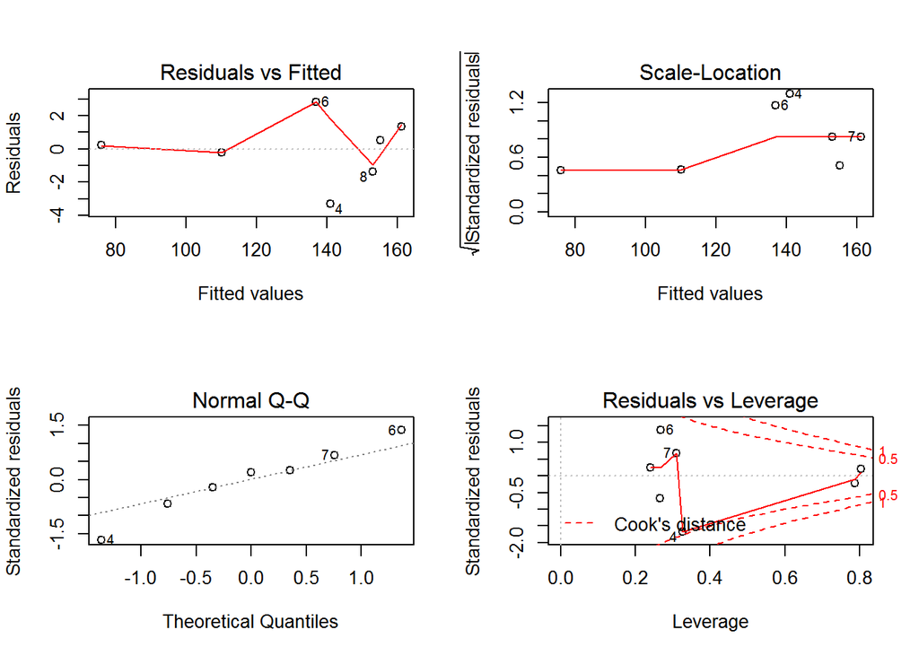

```r
layout(matrix(c(1,2,3,4),2,2))
plot(lm)
```

## Extracting the number of rows for the data where house price per square feet is to be calculated.

```r
T <- abc[N+2,1]
T
```

```
## [1] 4
```

## Extracting the test data.

```r
test<-abc[(N+3):(N+2+T),]
test
```

```
##      V1   V2 V3
## 10 0.49 0.18 NA
## 11 0.57 0.83 NA
## 12 0.56 0.64 NA
## 13 0.76 0.18 NA
```

## Predicting house price per square feet for test data.

```r
write(predict(lm,test),stdout())
```

```
## 105.2146 142.671 132.9361 129.7018
```

Above are the estimated house prices that Charlie could not get.